# WeRateDogs Twitter Data: Visualization Report

```python
import pandas as pd
import numpy as np
import requests
import json
import matplotlib.pyplot as plt
import seaborn as sns
import re
import warnings
import tweepy
import time
import os
sns.set_context()

plt.style.use('seaborn')
plt.figure(figsize=(12,8))

%matplotlib inline
```

```python
#import master data from data wrangling process

tweets_data_master = pd.read_csv('tweets_data_master.csv')
```

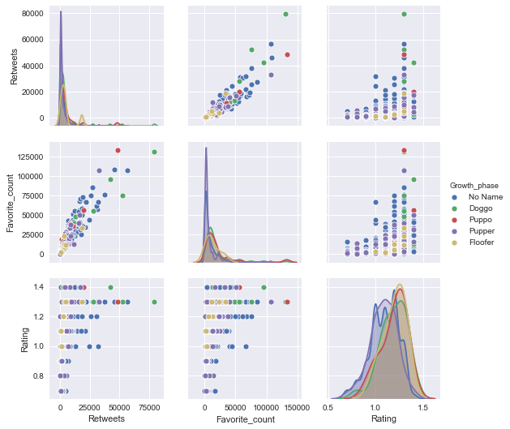

```python
ax1=sns.pairplot(tweets_data_master[['Growth_phase',"Retweets",'Day','Favorite_count','Rating']],hue='Growth_phase')
```

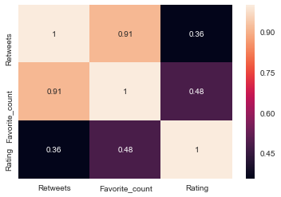

```python
ax2=sns.heatmap(tweets_data_master[['Growth_phase',"Retweets",'Day','Favorite_count','Rating']].corr(),annot=True)
```

#### The visual indicate there is a strong relationship between favorite count and retweets( mean dogs with high number of retweets are most likely to have high favorite counts). there is apoor relationship between rating and favorite count and also with retweets. this means high rating might not actually translate to high retweets or favorite counts.

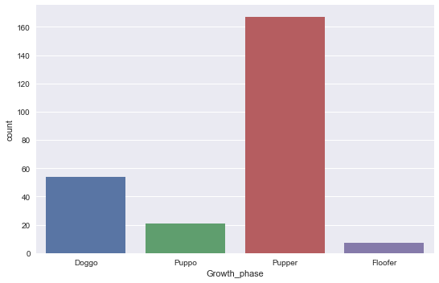

```python
sns.catplot(x="Growth_phase",kind='count',aspect=1.5,data=tweets_data_master[tweets_data_master["Growth_phase"]!="No Name"])
```

#### The dogs in pupper phase of growth have the highest count in the tweet data.

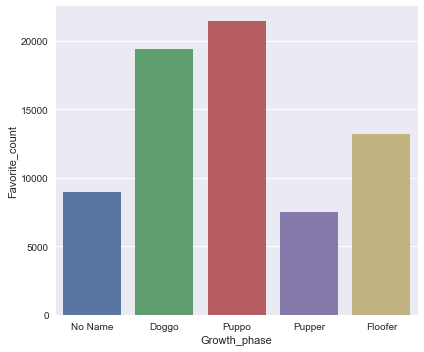

```python
sns.catplot(x='Growth_phase',y='Favorite_count',kind='bar',aspect=1.2,ci=None,data=tweets_data_master)
```

#### Dogs in the puppo and Doggo growth phase account for the heighest favorite counts

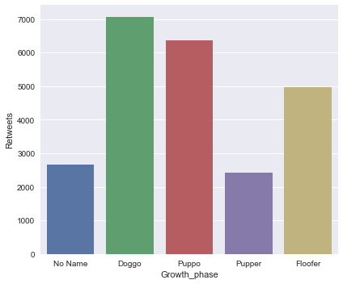

```python
sns.catplot(x='Growth_phase',y='Retweets',kind="bar", aspect=1.2,ci=None,data=tweets_data_master)
```

#### Dogs in the puppo and Doggo growth phase account for the heighest retweets

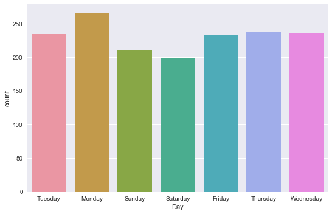

```python
sns.catplot(x='Day', kind='count',aspect=1.5,data=tweets_data_master)
```

#### The highest number of tweets occurred on monday while the least occurred on Saturday. Tuesday, Wednesday,Thursday and Friday have almost equal tweet count.

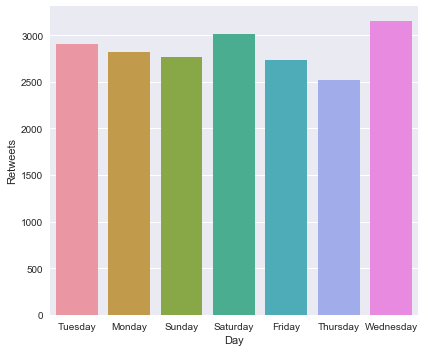

```python
sns.catplot(x='Day',y='Retweets',ci=None,kind='bar',aspect=1.2,data=tweets_data_master)
```

#### Although most tweets were posted on Monday, highest number of retweets occurred on Wednesday.

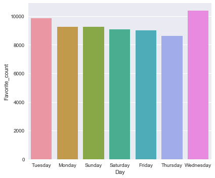

```python
sns.catplot(x='Day',y='Favorite_count',kind='bar', aspect=1.2, ci=None,data=tweets_data_master)
```

#### Although most tweets were posted on Monday, highest number of favorite count occurred on Wednesday. The information from retweets and favorite count indicate that highest activity occurred on Wednesday.

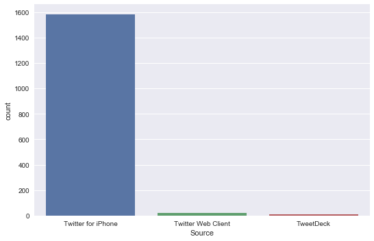

```python
sns.catplot('Source', kind='count',data=tweets_data_master,aspect=1.5)
```

#### Majority of the tweets (over 95%) were posted from iPhone.

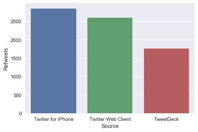

```python
sns.barplot(x='Source',y="Retweets",ci=None,data=tweets_data_master)
```

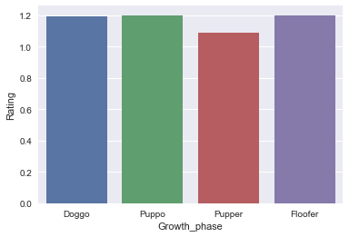

```python
sns.barplot(x='Growth_phase',y='Rating',ci=None,data=tweets_data_master[tweets_data_master["Growth_phase"]!="No Name"])
```